# Landcover Classification

Hope Hahn

2023-12-15

## Overview

Monitoring the distribution and change in land cover types can help us understand the impacts of phenomena like climate change, natural disasters, deforestation, and urbanization. Determining land cover types over large areas is a major application of remote sensing because we are able to distinguish different materials based on their spectral reflectance.

Classifying remotely sensed imagery into landcover classes enables us to understand the distribution and change in landcover types over large areas. There are many approaches for performing landcover classification – *supervised* approaches use training data labeled by the user, whereas *unsupervised* approaches use algorithms to create groups which are identified by the user afterward.

credit: this lab is based on a materials developed by Chris Kibler.

I am using a *decision tree classifier*. [Decision trees](https://medium.com/@ml.at.berkeley/machine-learning-crash-course-part-5-decision-trees-and-ensemble-models-dcc5a36af8cd) to classify pixels using a series of conditions based on values in spectral bands. These conditions (or decisions) are developed based on training data. I created a land cover classification for southern Santa Barbara County based on multi-spectral imagery and data on the location of 4 land cover types:

- green vegetation
- dry grass or soil
- urban
- water

#### *Data*

**Landsat 5 Thematic Mapper**

- [Landsat 5](https://www.usgs.gov/landsat-missions/landsat-5)
- 1 scene from September 25, 2007
- bands: 1, 2, 3, 4, 5, 7
- Collection 2 surface reflectance product

**Study area and training data**

- polygon representing southern Santa Barbara county
- polygons representing training sites
  - type: character string with land cover type

#### *Highlights of Analysis*

- load and process Landsat scene
- crop and mask Landsat data to study area
- extract spectral data at training sites
- train and apply decision tree classifier
- plot results

## Analysis

### *Data Preparation*

*Load Landsat Raster*

The first step in this analysis is creating a raster stack based on the 6 bands I will be working with. I created a raster stack by creating a list of the file names and read them in using the `rast` function. To further prepare this data, I updated the names of the raster layers to match the spectral bands and plot a true color image to visualize our raster.

```r
library(sf)
library(terra)
library(here)
library(dplyr)
library(rpart)
library(rpart.plot)
library(tmap)

rm(list = ls())
getwd()
```

```
## [1] "/Users/hopehahn/Documents/MEDS/COURSES/MEDS_eds223/final-project-repositories/landcover-classification/documents"
```

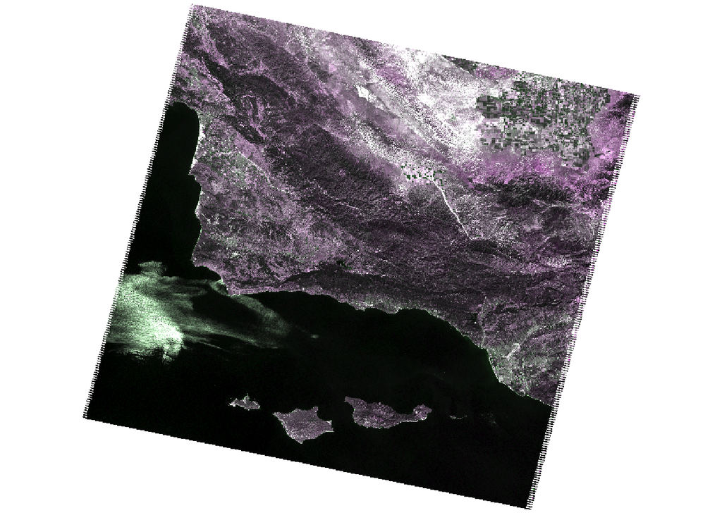

```r
# list files for each band, including the full file path
filelist <- list.files("../data/landsat-data/", full.names = TRUE)

# read in and store as a raster stack
landsat <- rast(filelist)

# update layer names to match band
names(landsat) <- c("blue", "green", "red", "NIR", "SWIR1", "SWIR2")

# plot true color image
plotRGB(landsat, r = 3, g = 2, blue = 1, stretch = "lin")
```

*Load study area*

The training data is only for the southern part of the county, so I read in a shapefile file that defines the area we would like to study. I converted the CRS to match the raster data and then plotted the shapefile to visualize the space I am working with.

```r
# read in shapefile for southern portion of SB county
SB_county_south <- st_read("../data/SB_county_south.shp")
```

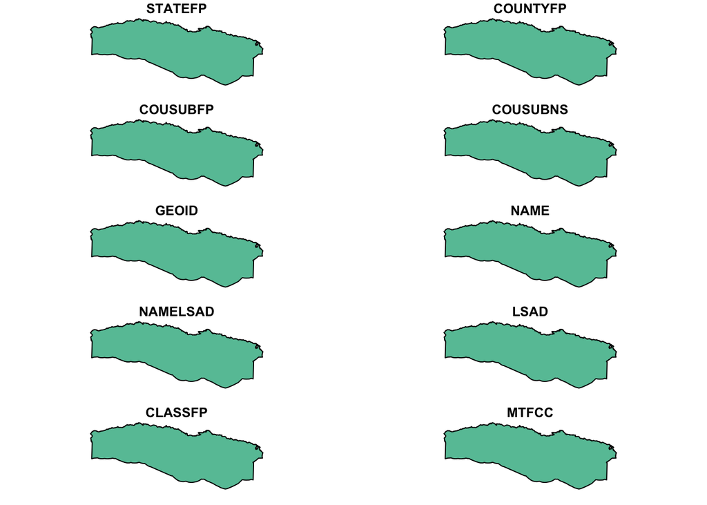

```r
# project to match the Landsat data
SB_county_south <- st_transform(SB_county_south, crs = st_crs(landsat))

plot(SB_county_south)
```

*Crop and mask Landsat data to study area*

I cropped the landsat raster data to match the south SB county data to reduces the amount of data and save computational time. I also removed objects I’m no longer working with to save space.

```r
# crop Landsat scene to the extent of the SB county shapefile
landsat_cropped <- crop(landsat, SB_county_south)

# mask the raster to southern portion of SB county
landsat_masked <- mask(landsat_cropped, SB_county_south)

# remove unnecessary object from environment
rm(landsat, landsat_cropped, SB_county_south)
```

*Convert Landsat values to reflectance*

I converted the values in the raster stack to correspond to reflectance values by removing erroneous values and applying any [scaling factors](https://www.usgs.gov/faqs/how-do-i-use-scale-factor-landsat-level-2-science-products#:~:text=Landsat%20Collection%202%20surface%20temperature,the%20scale%20factor%20is%20applied.) to convert to reflectance.

The valid range of pixel values for this collection 7,273-43,636, with a multiplicative scale factor of 0.0000275 and an additive scale factor of -0.2. I reclassified any erroneous values as `NA` and updated the values for each pixel based on the scaling factors, so the pixel values range from 0-100%.

```r
summary(landsat_masked)
```

```
##       blue           green            red             NIR
##  Min.   : 7675   Min.   : 7543   Min.   : 7274   Min.   : 7248
##  1st Qu.: 8178   1st Qu.: 8063   1st Qu.: 7667   1st Qu.: 7545
##  Median : 8387   Median : 8941   Median : 8890   Median :12507
##  Mean   : 8668   Mean   : 9097   Mean   : 9062   Mean   :11460
##  3rd Qu.: 8955   3rd Qu.: 9730   3rd Qu.: 9965   3rd Qu.:14306
##  Max.   :65535   Max.   :26662   Max.   :27885   Max.   :28029
##  NA's   :39855   NA's   :39855   NA's   :39855   NA's   :39855
##      SWIR1           SWIR2
##  Min.   : 7025   Min.   : 6936
##  1st Qu.: 7419   1st Qu.: 7356
##  Median :11940   Median : 9824
##  Mean   :11372   Mean   :10007
##  3rd Qu.:13962   3rd Qu.:11740
##  Max.   :25139   Max.   :24752
##  NA's   :39855   NA's   :39855
```

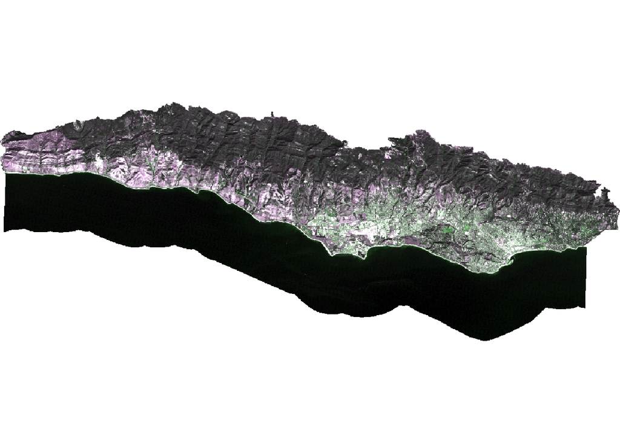

```r
# reclassify erroneous values as NA
rcl <- matrix(c(-Inf, 7273, NA,
                43636, Inf, NA),
       ncol = 3, byrow = TRUE)

# reclassify landsat data
landsat <- classify(landsat_masked, rcl = rcl)

# adjust values based on scaling factor
landsat <- (landsat * 0.0000275 - 0.2) * 100

# plot true color image to check results
plotRGB(landsat_masked, r = 3, g = 2, blue = 1, stretch = "lin")
```

```r
# check values are 0 - 100
summary(landsat)
```

```
##       blue           green            red             NIR
##  Min.   : 1.11   Min.   : 0.74   Min.   : 0.00   Min.   : 0.23
##  1st Qu.: 2.49   1st Qu.: 2.17   1st Qu.: 1.08   1st Qu.: 0.75
##  Median : 3.06   Median : 4.59   Median : 4.45   Median :14.39
##  Mean   : 3.83   Mean   : 5.02   Mean   : 4.92   Mean   :11.52
##  3rd Qu.: 4.63   3rd Qu.: 6.76   3rd Qu.: 7.40   3rd Qu.:19.34
##  Max.   :39.42   Max.   :53.32   Max.   :56.68   Max.   :57.08
##  NA's   :39856   NA's   :39855   NA's   :39855   NA's   :39856
##      SWIR1           SWIR2
##  Min.   : 0.10   Min.   : 0.20
##  1st Qu.: 0.41   1st Qu.: 0.60
##  Median :13.43   Median : 8.15
##  Mean   :11.88   Mean   : 8.52
##  3rd Qu.:18.70   3rd Qu.:13.07
##  Max.   :49.13   Max.   :48.07
##  NA's   :42892   NA's   :46809
```

### *Classify image*

*Extract reflectance values for training data*

I loaded the shapefile identifying different locations within the study area as containing one of our 4 land cover types. I then extracted the spectral values at each site to create a data frame that relates land cover types to their spectral reflectance.

```r
# read in and transform training data
training_data <- st_read("../data/trainingdata.shp") %>%
  st_transform(., crs = st_crs(landsat))
# extract reflectance values at training sites
training_data_values <- terra::extract(landsat, training_data, df = TRUE)

# convert training data to data frame
training_data_attributes <- training_data %>%
  st_drop_geometry()

# join training data attributes and extracted reflectance values
SB_training_data <- left_join(training_data_values, training_data_attributes, by = c("ID" = "id")) %>%
  mutate(type = as.factor(type))
```

*Train decision tree classifier*

To train the decision tree, I first established the model formula (i.e. what our response and predictor variables are). The `rpart` function implements the [CART algorithm](https://medium.com/geekculture/decision-trees-with-cart-algorithm-7e179acee8ff). The `rpart` function needs to know the model formula and training data you would like to use. Because I am performing a classification, we set `method = "class"`. We also set `na.action = na.omit` to remove any pixels with `NA`s from the analysis.

To understand how the decision tree will classify pixels, I plotted the results. The decision tree is comprised of a hierarchy of binary decisions. Each decision rule has 2 outcomes based on a conditional statement pertaining to values in each spectral band.

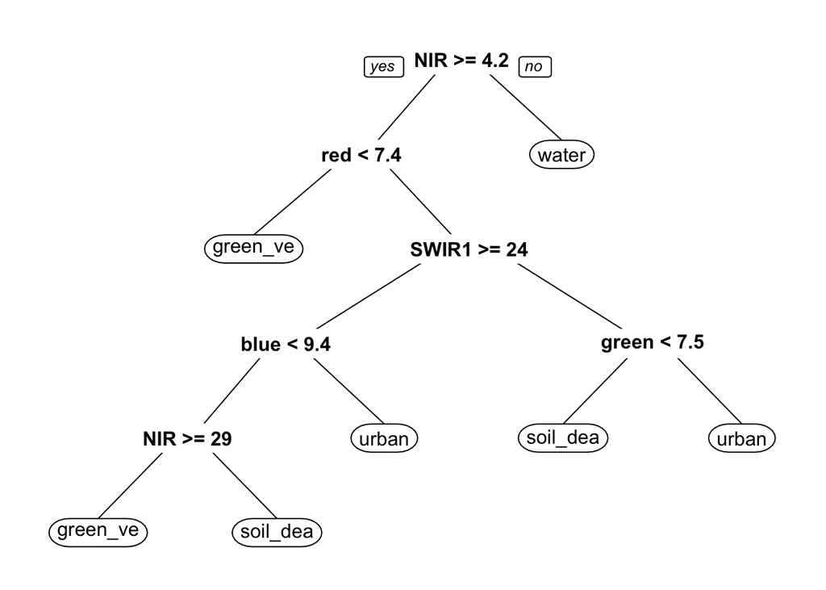

```r
# establish model formula
SB_formula <- type ~ red + green + blue + NIR + SWIR1 + SWIR2

# train decision tree
SB_decision_tree <- rpart(formula = SB_formula,
      data = SB_training_data,
      method = "class",
      na.action = na.omit)

# plot decision tree
prp(SB_decision_tree)
```

*Apply decision tree*

I then applied the decision tree to the entire image. The `terra` package includes a `predict()` function that applys a model to the data. In order for this to work properly, the names of the layers need to match the column names of the predictors used to train the decision tree. The `predict()` function will return a raster layer with integer values. These integer values correspond to the *factor levels* in the training data. To figure out what category each integer corresponds to, I inspected the levels of our training data.

```r
# classify image based on decision tree
SB_classification <- predict(landsat, SB_decision_tree, type = "class", na.rm = TRUE)

# inspect level to understand the order of classes in prediction
levels(SB_training_data$type)
```

```
## [1] "green_vegetation" "soil_dead_grass"  "urban"            "water"
```

#### Plot results

Now we can plot the results and check out our land cover map!

```
## SpatRaster object downsampled to 621 by 1612 cells.
```

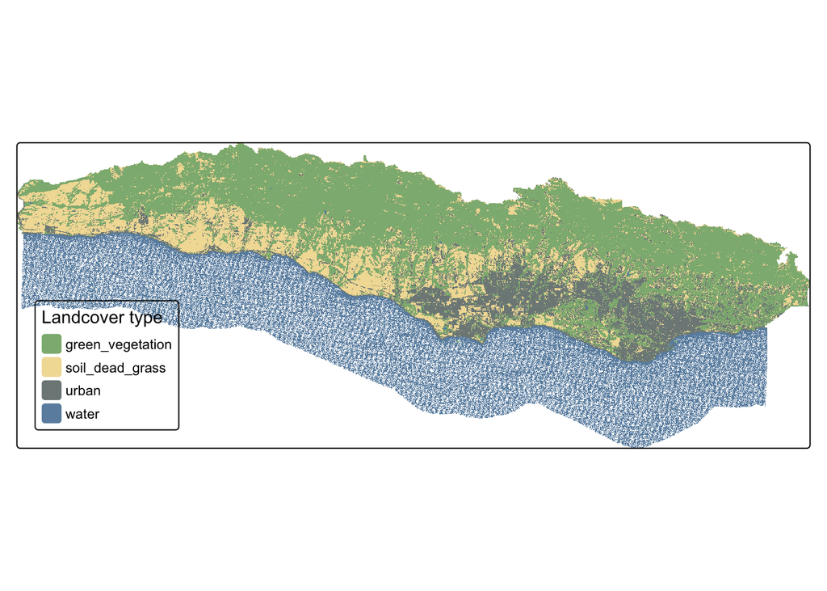

```r
# plot results
tm_shape(SB_classification) +
  tm_raster(col.scale = tm_scale_categorical(values = c("#8DB580", "#F2DDA4", "#7E8987", "#6A8EAE")),
            col.legend = tm_legend(labels = c("green vegetation", "soil/dead grass", "urban", "water"),
                                   title = "Landcover type")) +
  tm_layout(legend.position = c("left", "bottom"))
```